# How Economic Decline Changes the Business Environment

Stephen Weymouth

Dean’s Professor

2026-11-04

# In August 2003 Fruit of the Loom said it would close its mill in Cameron County, Texas, and move the work to Honduras.

## Your IB Voice

From a closed mill to a vote

Boo’s laid-off workers did not blame trade or the company that left. Using Broz, Frieden, and Weymouth, explain how a plant closing can still turn into a political backlash years later.

**10 minutes** · Individual · Notes permitted · No internet/LLMs

## Competing explanations

Why do places that lose their factories turn to populists?

Workers who end up in worse jobs turn against the parties in power, even if they never blamed trade.

When a plant closes the whole town declines, including people who kept their jobs.

The people who could leave have left, and those who stayed are stuck.

Politicians blame trade because trade, unlike technology, is a policy. People follow political cues.

# What happens when the mill closes?

## Cameron County lost most of its factory jobs

[figure not shown]

U.S. Bureau of Labor Statistics, *State and Metro Area Employment*, via [FRED](https://fred.stlouisfed.org/series/SMU48151803000000001A), 2026: manufacturing, Brownsville-Harlingen, Texas.

Levi’s, Wrangler, Converse, and Haggar closed their plants there in the four years before Fruit of the Loom.

The jobs that paid decently without a degree were the ones that left.

## Lupita Sanchez’s family fell below the poverty line

Lupita sewed and then supervised at a mill that made Disney T-shirts.

After it closed in 2001 she earned a high-school equivalency diploma and two certificates, and then sold lunches at building sites.

[figure not shown]

Boo, “The Churn,” *The New Yorker*, 2004.

Retraining did not bring back the income the mill had paid.

## Retraining could not replace the lost jobs

[figure not shown]

Boo, “The Churn,” *The New Yorker*, 2004.

Federal retraining money flowed, but there were too few decent jobs to train for.

The paper finds that each factory job lost costs about 1.6 other local jobs.

Food-stamp applications rose 15 percent in a year.

*Local economic spillovers* are the effects of one employer’s gains or losses on others in the same place.

## The workers did not blame the countries that won

[figure not shown]

Boo, “The Churn,” *The New Yorker*, 2004.

Many had relatives in Mexico who earned in a week what a U.S. worker earned in a day.

They blamed themselves for failing to find work.

Of the mill’s closing, workers said, “That was just the way the system worked.”

# “One company, just one, and the whole region feels completely different.” Mayor Connie de la Garza of Harlingen

# Cameron County bid for Boeing’s new Dreamliner plant, offering cheap, retrained labor. In December 2003 Boeing chose Everett, Washington.

# How did the backlash grow?

## Work moved from farms to factories to services

[figure not shown]

Herrendorf, Rogerson, and Valentinyi, *Historical Employment and Output by Sector*, 2017, via [Our World in Data](https://ourworldindata.org/grapher/employment-by-economic-sector): U.S. employment in agriculture, industry, and services.

As machines let fewer farmers feed everyone, workers moved into factories; as factories needed fewer workers, they moved into services.

*Structural change* is the shift of workers among farming, industry, and services as an economy grows.

## Factories doubled output with fewer workers

[figure not shown]

Federal Reserve and U.S. Bureau of Labor Statistics via [FRED](https://fred.stlouisfed.org/series/IPMAN), 2026: industrial production, manufacturing, and manufacturing jobs.

Productivity rose faster in factories than in services, so goods took fewer workers.

Richer households spent more on services such as health care and education.

Chinese imports explain about a quarter of factory jobs lost from 1990 to 2007.

*Deindustrialization* is the long fall in manufacturing’s share of jobs.

## Manufacturing jobs shrank across rich countries

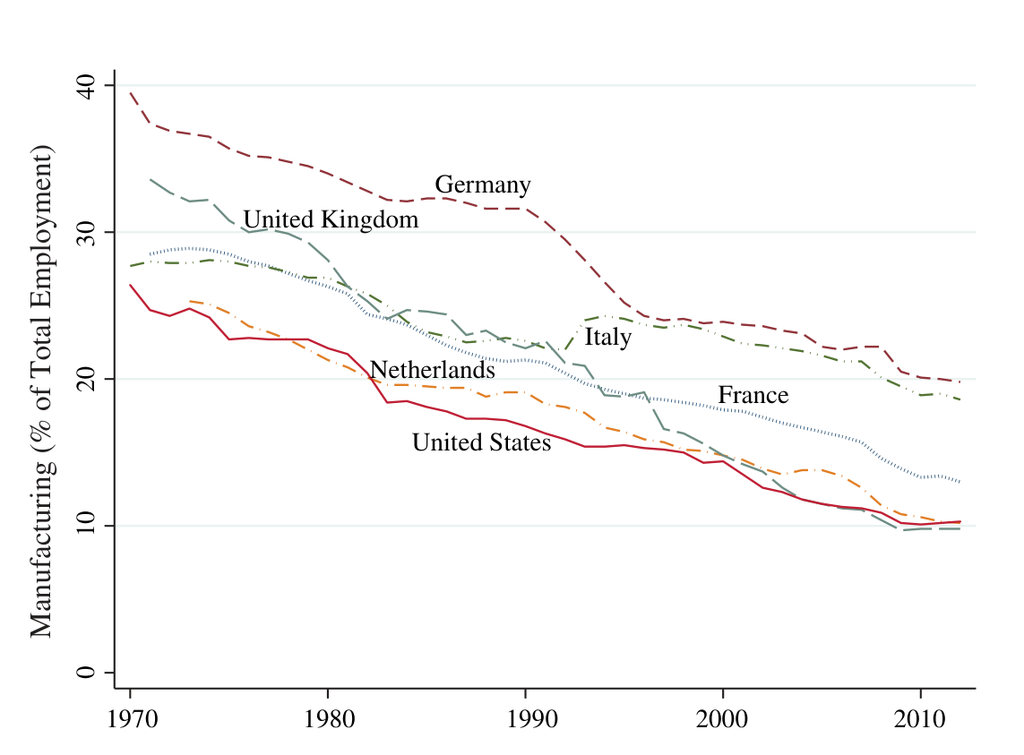

Broz, Frieden, and Weymouth, “Populism in Place,” *International Organization*, 2021, Figure 2.

The decline began in the 1960s, as manufactured exports from low-wage countries grew.

Germany and Italy kept more factory jobs than Britain and the United States, but every country lost them.

Backlash differs: Brexit, Trump, French riots…

## Old factory counties kept falling behind

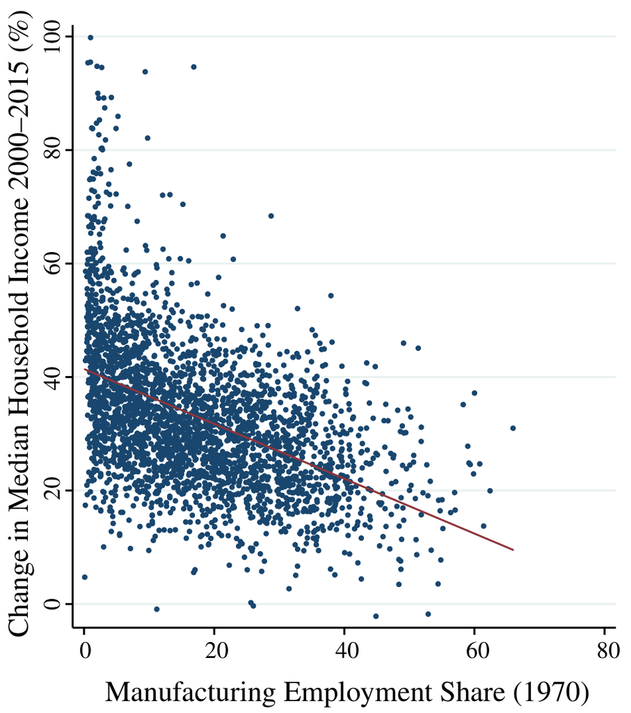

Broz, Frieden, and Weymouth, “Populism in Place,” *International Organization*, 2021, Figure 3, right panel.

The counties that depended most on factories in 1970 had the slowest income growth after 2000.

The same counties lost the most factory jobs and saw the largest falls in the share of adults working.

Decline that began in the factories spread to the rest of the county’s economy.

# When the factories close, the town around them declines too.

## Populists speak for “the people” against elites

### Left-wing populism

Blames corporations, financial elites, and austerity for inequality.

Bernie Sanders in the United States is one example.

### Right-wing populism

Blames immigrants, trade, and international institutions, and promises nationalism, law and order, and protection.

Donald Trump is the leading example.

*Populism* is a politics that claims to represent “the people” against corrupt elites who have failed ordinary citizens.

# “The appropriate unit of analysis for studying populism is the community, not the individual.” Broz, Frieden, and Weymouth

## Measuring populism: where Trump outperformed Romney

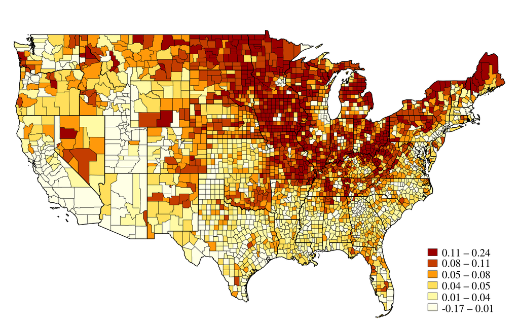

Broz, Frieden, and Weymouth, “Populism in Place,” *International Organization*, 2021, Figure 1.

The darkest counties are old factory and farm towns, not the big cities.

## Trump gained most in struggling counties

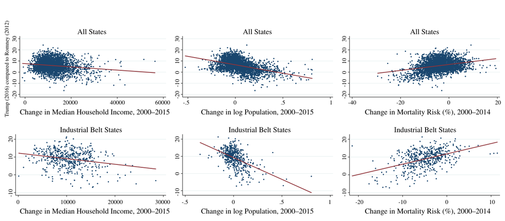

Broz, Frieden, and Weymouth, “Populism in Place,” *International Organization*, 2021, Figure 6.

Trump did better than Romney where incomes grew slowly, people moved away, and more adults died young, and the pattern was strongest in the industrial belt.

The backlash tracked the health of the place, not only the voter’s own job.

## Counties that lost more factory jobs swung harder

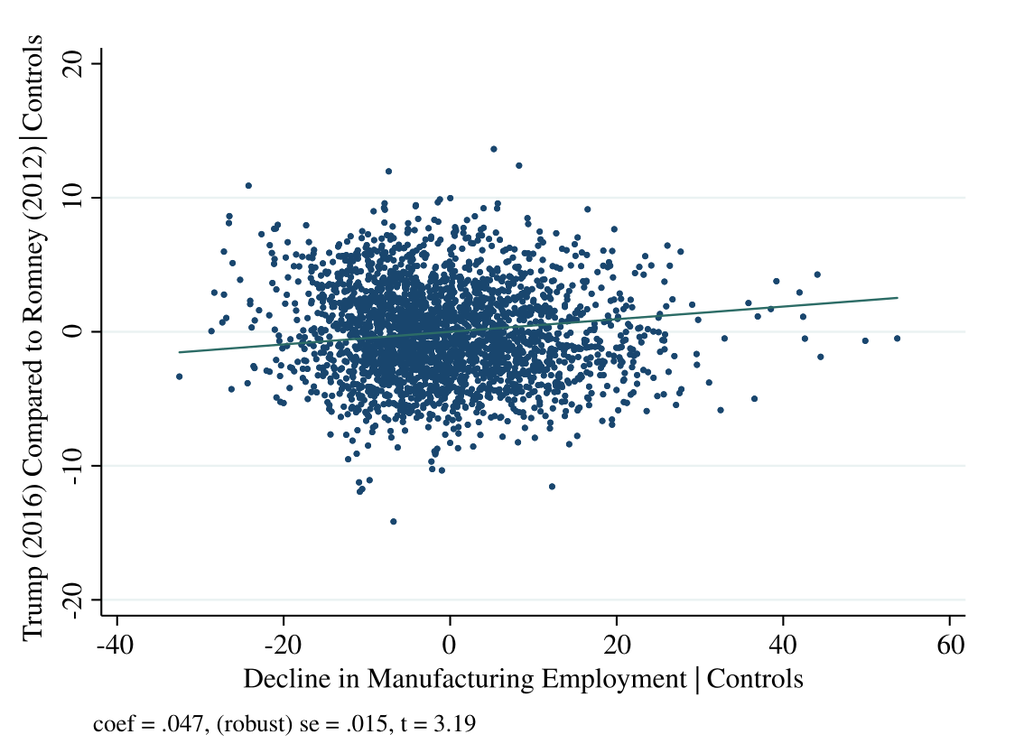

Broz, Frieden, and Weymouth, “Populism in Place,” *International Organization*, 2021, Figure 7.

The link holds after accounting for age, race, education, population, and imports from China.

Counties with more business-service jobs swung the other way.

## Economy or identity

Do people in declining places turn to populists because they lost income, or because they feel their group has lost status?

# What happened in Cameron County?

## Cameron County swung right in 2024, then back

[figure not shown]

County presidential returns, 2000 to 2024, compiled by [akashic.app](https://www.akashic.app/counties/48061), 2026. 2026 results: [Cameron County Elections](https://www.livevoterturnout.com/ENR/camerontxenr/46/en/Index_46.html), unofficial, November 3, 2026.

The county voted Democratic in every presidential election from 2008 to 2020.

The swing came twenty years after the mills closed.

In yesterday’s midterms, Democrats won about two-thirds of the county’s vote for Senate and governor.

Does the paper explain this swing, or do we need something more?

## Trade Adjustment Assistance lapsed in 2022

[figure not shown]

Trade Expansion Act of 1962; Trade Act of 1974; Trade Adjustment Assistance Reform Act of 2002; Trade and Globalization Adjustment Assistance Act of 2009; Trade Adjustment Assistance Reauthorization Act of 2015.

Critics say its training rarely raised pay, and that it ignored jobs lost to automation.

What would help workers like Lupita more?

# Spend the county’s $1.6 million

## Choose one use for the grant

1. **Choose** one use for the $1.6 million emergency grant (roughly $2,000 per worker): updated retraining, moving grants for workers who take jobs elsewhere, pay extra for workers who take lower-paying jobs, incentives for a new employer, or something else.
2. **Diagnose** whether it helps the worker, the place, or both
3. **Name** one harm from Broz, Frieden, and Weymouth that it does not fix.
4. **Explain** your choice to the person next to you.

**10 minutes** · Individual, then pairs · Readings permitted

## Populist politics now shapes globalization

[figure not shown]

Screenshots of ABC News (*Good Morning America*), April 2, 2025; PBS News (Associated Press), January 7, 2026; CBS News, February 21, 2026; *Reason*, May 13, 2026; Brookings, June 9, 2026; DHL Group, October 7, 2026.

Trade keeps growing, but its rules now depend on who wins elections

## Takeaways

Why does economic decline become political?

A plant closing cuts the income of the workers who lose their jobs, and retraining rarely restores it.

The losses spread to stores, home values, and the local budget.

Workers who cannot leave stay in places that keep falling behind.

Over decades those places turn against the parties and global order that they associate with the decline.

Decline becomes political through places, not only through people.